# Risk Variants Inference using Epigenomic Reference Annotations (RiVIERA)

## Brief introduction

RiVIERA is a probabilistic framework to infer functional enrichments and prioritize causal variants using summary statistics and epigenomic or other functional genomic annotations. Specifically, RiVIERA can be divided into two stages: (1) RiVIERA-ench: genome-wide enrichment estimations; (2) RiVIERA-fmap: fine-mapping causal variants. We demonstrate how to run both in the following tutorial.

## Genome-wide enrichment estimations

### Data preparation

To run RiVIERA-ench, we will need the following data. Suppose M SNPs, K annotations, G groups over the K annotations, then the folowing data matrices are expected:

1. GWAS summary statistics in terms p-values in a numerical vector (M x 1)
2. Functional annotation matrix (binary or continuous) for each SNP (M x K)
3. Annotatoin by group binary matrix indicating what group each annotatoin belongs to. This is required only for the group-guided sparse enrichment model (M x G)
4. Linkage disequilibrium (LD) either from the GWAS cohort or reference panel (e.g. 1000 Genome Project)

For illustration purpose, we provide a simulated dataset saved in RData file and loaded as follows. In this simulated dataset, there are 100 causal variants out of 17225 variants and 10 annotations. The causal annotatoins are the first 3 annotatoins.

### Genome-wide enrichment estiamtions

We first demonstrate inferring genome-wide enrichment using an efficient regularized log-likelihood model.

```r
library(RiVIERA)
rda <- system.file("extdata/seed10.RData", package="RiVIERA")

if(!file.exists(rda)) {
  rda <- list.files("~/Projects/riviera/simdata",".RData$",full.names=T)[1]
}

load(rda)

gwas_pval <- unlist(simdata$gwasPval[[1]])

ann <- simdata$ann

res <- riviera_ridge(gwas_pval,
                     ann,
                     ann_w_mu=rep(0, ncol(ann)),
                     minPval=1e-50,
                     alpha0=0.1,
                     pri0=1e-3,
                     epsilon=1,
                     thres=1e-4,
                     max_iter=100)
```

```
## Estimate parameters by model by EM:
## iter 1: lpr = -126855; N1 = 647.553; alpha = 0.1; pri0 = 0.001; diff = 1
## iter 2: lpr = -543135; N1 = 647.553; alpha = 0.0521903; pri0 = 1; diff = 0.766439
## iter 3: lpr = -113265; N1 = 17225; alpha = 0.487348; pri0 = 0.001; diff = 3.79526
## iter 4: lpr = -295907; N1 = 414.92; alpha = 0.0437852; pri0 = 1; diff = 0.617228
## iter 5: lpr = -111952; N1 = 17224.9; alpha = 0.487347; pri0 = 0.00107928; diff = 1.64316
## iter 6: lpr = -276443; N1 = 422.683; alpha = 0.0441971; pri0 = 0.999999; diff = 0.595026
## iter 7: lpr = -109605; N1 = 17224.8; alpha = 0.487344; pri0 = 0.00123702; diff = 1.52217
## iter 8: lpr = -239548; N1 = 437.165; alpha = 0.0449652; pri0 = 0.999993; diff = 0.542451
## iter 9: lpr = -95068.4; N1 = 17223.8; alpha = 0.487324; pri0 = 0.00288143; diff = 1.51975
## iter 10: lpr = -89888.2; N1 = 548.506; alpha = 0.0508481; pri0 = 0.980924; diff = 0.0576296
## iter 11: lpr = -37091.5; N1 = 14891.9; alpha = 0.438657; pri0 = 0.0923217; diff = 1.42342
## iter 12: lpr = -38625.3; N1 = 2512.23; alpha = 0.136726; pri0 = 0.158471; diff = 0.0397104
## iter 13: lpr = -39321.5; N1 = 2686.49; alpha = 0.133919; pri0 = 0.15284; diff = 0.0177059
## iter 14: lpr = -39937.8; N1 = 2617.29; alpha = 0.131417; pri0 = 0.148862; diff = 0.0154312
## iter 15: lpr = -40403.6; N1 = 2566.78; alpha = 0.129578; pri0 = 0.145892; diff = 0.0115291
## iter 16: lpr = -40754.5; N1 = 2529.35; alpha = 0.12821; pri0 = 0.143698; diff = 0.00861051
## iter 17: lpr = -41017.1; N1 = 2501.74; alpha = 0.127197; pri0 = 0.142082; diff = 0.00640119
## iter 18: lpr = -41212.4; N1 = 2481.42; alpha = 0.12645; pri0 = 0.140895; diff = 0.00473804
## iter 19: lpr = -41356.9; N1 = 2466.51; alpha = 0.1259; pri0 = 0.140025; diff = 0.00349472
## iter 20: lpr = -41463.5; N1 = 2455.57; alpha = 0.125497; pri0 = 0.139387; diff = 0.00257073
## iter 21: lpr = -41541.9; N1 = 2447.57; alpha = 0.125201; pri0 = 0.13892; diff = 0.00188721
## iter 22: lpr = -41599.4; N1 = 2441.71; alpha = 0.124985; pri0 = 0.138579; diff = 0.00138334
## iter 23: lpr = -41641.6; N1 = 2437.43; alpha = 0.124826; pri0 = 0.138329; diff = 0.00101286
## iter 24: lpr = -41672.5; N1 = 2434.3; alpha = 0.12471; pri0 = 0.138147; diff = 0.000740995
## iter 25: lpr = -41695.1; N1 = 2432.01; alpha = 0.124626; pri0 = 0.138014; diff = 0.000541772
## iter 26: lpr = -41711.6; N1 = 2430.34; alpha = 0.124564; pri0 = 0.137916; diff = 0.000395936
## iter 27: lpr = -41723.7; N1 = 2429.12; alpha = 0.124519; pri0 = 0.137845; diff = 0.000289262
## iter 28: lpr = -41732.5; N1 = 2428.23; alpha = 0.124486; pri0 = 0.137794; diff = 0.000211279
## iter 29: lpr = -41738.9; N1 = 2427.58; alpha = 0.124462; pri0 = 0.137756; diff = 0.000154292
## iter 30: lpr = -41743.6; N1 = 2427.11; alpha = 0.124444; pri0 = 0.137728; diff = 0.000112661
## iter 31: lpr = -41747.1; N1 = 2426.76; alpha = 0.124431; pri0 = 0.137708; diff = 8.22557e-05
```

```r
ann_w <- res$ann_w

rownames(ann_w) <- colnames(ann)

#### significance test ####
scaler <- 1.96 # 95% CI

ann_w_se <- res$ann_w_se[-1] # remove intercept

upper <- ann_w + scaler * ann_w_se
lower <- ann_w - scaler * ann_w_se

ann_w_zscore <- res$ann_w_zscore

enrichment <- data.frame(ann=1:10,
                         causal=c(rep(TRUE,3),rep(FALSE,7)),
                         enrichment_zscore=ann_w_zscore,
                         ann_w=ann_w, w_se=ann_w_se,
                         ann_w_pval = 2*pnorm(-abs(ann_w_zscore)),
                         upper=upper, lower=lower)

print(enrichment)
```

```
##    ann causal enrichment_zscore      ann_w      w_se   ann_w_pval
## 1    1   TRUE         5.6854432  2.8076403 0.4938296 1.304738e-08
## 2    2   TRUE         6.1613701  2.9177425 0.4735542 7.211820e-10
## 3    3   TRUE         5.8210571  2.9438380 0.5057222 5.847658e-09
## 4    4  FALSE         1.2786390  0.4981669 0.3896071 2.010242e-01
## 5    5  FALSE        -0.3973614 -0.1881467 0.4734900 6.911010e-01
## 6    6  FALSE        -1.1261709 -0.6007350 0.5334314 2.600932e-01
## 7    7  FALSE        -1.4869106 -0.8602101 0.5785217 1.370384e-01
## 8    8  FALSE         0.5684465  0.2370786 0.4170641 5.697318e-01
## 9    9  FALSE        -1.1506726 -0.6223578 0.5408644 2.498670e-01
## 10  10  FALSE         1.7703064  0.6632987 0.3746802 7.667612e-02
##        upper       lower
## 1  3.7755464  1.83973426
## 2  3.8459086  1.98957632
## 3  3.9350536  1.95262244
## 4  1.2617969 -0.26546311
## 5  0.7398938 -1.11618716
## 6  0.4447906 -1.64626058
## 7  0.2736925 -1.99411271
## 8  1.0545244 -0.58036707
## 9  0.4377364 -1.68245190
## 10 1.3976719 -0.07107444
```

We now display the enrichment in terms of the estimated p-values, where the causal annotations are disguished from the non-causal ones by the bar color.

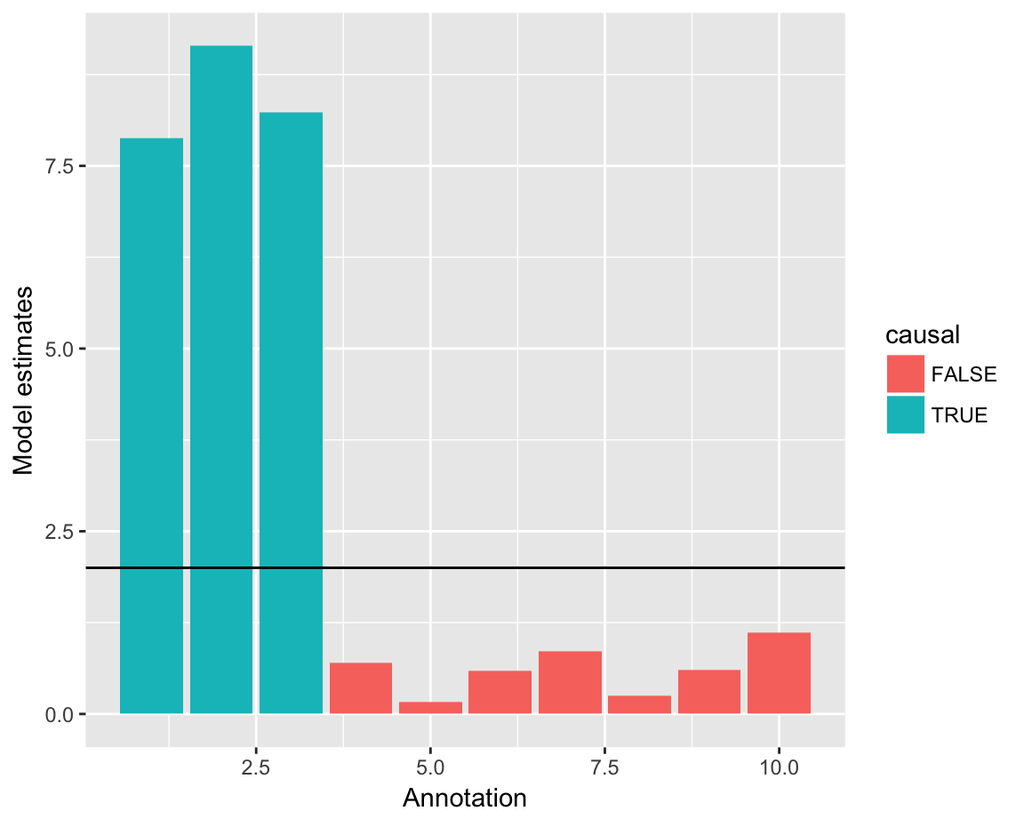

```r
library(ggplot2)

ggplot(enrichment, aes(x=ann, y=-log10(ann_w_pval), fill=causal)) +
  geom_bar(stat="identity", position='dodge') +
  xlab("Annotation") + geom_hline(yintercept = 2) +
  ylab("Model estimates")
```

### Fine-mapping causal variants

We now demonstrate the fine-mapping component of RiVIERA framework using the same simulated data. Here we incorporate the LD information along with summary statistics z-scores and annotations. Notably, we can also use the above enrichments as the prior information by setting the “ann_w_mu” option. We filter out the loci that don’t harbor any causal SNPs and retain 9939 variants and 55 risk loci each harboring at least one causal SNP.

```r
risklociIdx <- which(simdata$causalcnt > 0)

riskloci_risd <- unlist(simdata$snpidByBlocks[risklociIdx])

zscore <- simdata$gwasZval[riskloci_risd,,drop=F]

ldmatList <- simdata$transformedLD[risklociIdx]

ann <- simdata$ann[riskloci_risd,]

is_causal <- simdata$is_causal[[1]][riskloci_risd]
```

To fine-map causal variants, we implemented two sampling schemes (configSampleScheme) namely (1) stochastic neighborhood search (nbh); and (2) importance sampling. The former is more accurate when the in-sample LD is used (i.e., LD was estimated directly from the GWAS cohort), which is the case in our simulation. However, the latter has the benifits of being more efficient, emphasizing on the SNPs with large z-scores, and less dependent on the correctness of LD matrix espeically when the LD is estiamted from a reference panel rather than from the GWAS cohort.

```r
#### model parameters ####
step_W <- 1e-2
nsteps_W <- 100

step_S <- 1e-3
nsteps_S <- 100

thres <- 1e-5

burninFrac <- 0.2

randomSeed <- 23

set.seed(randomSeed)

# 1: nbh; 2: imp
configSampleScheme <- 1

sampleSize <- 10

max_iter <- 10

res <- riviera_fmap(zscore=zscore,
                    ldmat=ldmatList,
                    ann=ann,
                    ann_w_mu=rep(0,ncol(ann)),
                    ann_w_sigma0=diag(ncol(ann),ncol(ann)),
                    configSampleScheme=configSampleScheme,
                    step_W = step_W,
                    nsteps_W = nsteps_W,
                    step_S = step_S,
                    nsteps_S = nsteps_S,
                    max_iter=max_iter,
                    sampleSize=sampleSize,
                    thres=thres,
                    verboseS=F,
                    verboseW=F,
                    verboseC=F)
```

```
## Settings:
## max_iter = 10
## step_W = 0.01; nsteps_W = 100
## step_S = 0.001; nsteps_S = 100
## configSampleScheme (1: nbh; 2: imp)= 1
## 9939 SNPs
## 10 annotations
## 55 loci
## 1, lprS: 681.961; lprS_diff: 1; AFS: 0 (0%), lprW: -562.029; lprW_diff: 1; ann_w_diff: 1; AFW: 0 (0%)
## 2, lprS: 681.961; lprS_diff: 0; AFS: 0 (0%), lprW: -568.405; lprW_diff: -6.37682; ann_w_diff: 1; AFW: 1 (50%)
## 3, lprS: 695.651; lprS_diff: 13.6899; AFS: 1 (33%), lprW: -555.247; lprW_diff: 13.1586; ann_w_diff: 1; AFW: 2 (67%)
## 4, lprS: 721.409; lprS_diff: 25.7589; AFS: 2 (50%), lprW: -572.337; lprW_diff: -17.0902; ann_w_diff: 0.65274; AFW: 3 (75%)
## 5, lprS: 782.902; lprS_diff: 61.4928; AFS: 3 (60%), lprW: -490.43; lprW_diff: 81.9066; ann_w_diff: 0.286181; AFW: 4 (80%)
## 6, lprS: 799.806; lprS_diff: 16.9036; AFS: 4 (67%), lprW: -447.587; lprW_diff: 42.8436; ann_w_diff: 0.163742; AFW: 5 (83%)
## 7, lprS: 817.072; lprS_diff: 17.2666; AFS: 5 (71%), lprW: -444.842; lprW_diff: 2.74442; ann_w_diff: 0.118366; AFW: 6 (86%)
## 8, lprS: 825.16; lprS_diff: 8.08731; AFS: 5 (63%), lprW: -462.614; lprW_diff: -17.7722; ann_w_diff: 0.118366; AFW: 7 (88%)
## 9, lprS: 825.16; lprS_diff: 0; AFS: 5 (56%), lprW: -463.294; lprW_diff: -0.67987; ann_w_diff: 0.118366; AFW: 8 (89%)
## 10, lprS: 825.16; lprS_diff: 0; AFS: 5 (50%), lprW: -457.444; lprW_diff: 5.85058; ann_w_diff: 0.118366; AFW: 9 (90%)
## MCMC inference completed.
## Accepted models: 6
```

```r
burnFrac <- 0.2

burnIdx <- 1:round(burnFrac * res$fit_info$ensembleSize)

# SNP posterior inclusion probabilities (PIP)
pip <- rowMeans(res$ensemble$pip_ensemble[,-burnIdx])

# enrichment weights
w <- res$ensemble$ann_w_ensemble[,-burnIdx,drop=F]

rownames(w) <- sprintf("A%s", 1:nrow(w))

enrichDf <- melt(w)

enrichDf$causal <- enrichDf$X1 %in% sprintf("A%s", 1:3)

annOrder <- levels(enrichDf$X1)[order(as.numeric(sub("A","",levels(enrichDf$X1))))]

enrichDf$X1 <- factor(enrichDf$X1, levels=annOrder)
```

Below we display the distribution of the enrichments and the accuracy of inferring the causal variants in terms of precision-recall.

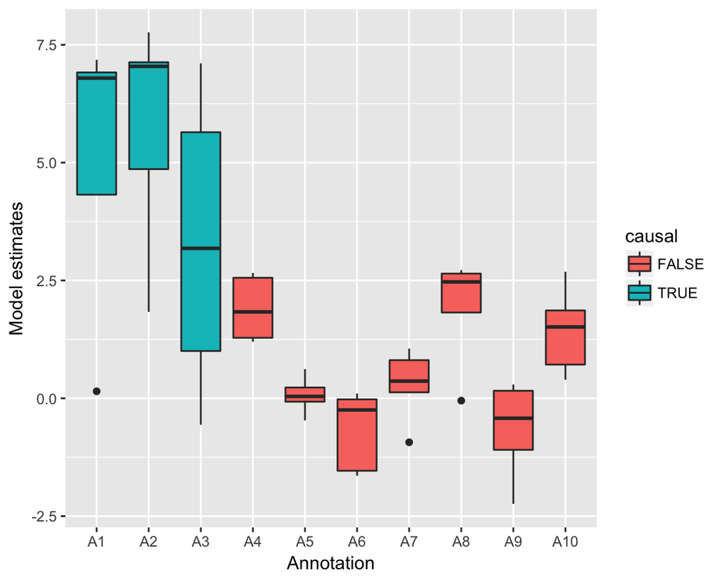

```r
library(ggplot2)

ggplot(enrichDf, aes(x=X1, y=value, fill=causal)) +
  geom_boxplot() +
  xlab("Annotation") +
  ylab("Model estimates")
```

```r
source(system.file("extdata/eval_funs.R", package="RiVIERA"))

library(ROCR)
library(scales)

predList <- list(`RiVIERA`=pip, `-log10(pval)`=-log10(2*pnorm(-abs(zscore))))

powanal_roc <- do.call(rbind, lapply(names(predList), function(x)
  roceval(predList[[x]], is_causal, x)))

powanal_prc <- do.call(rbind, lapply(names(predList), function(x)
  prceval(predList[[x]], is_causal, x)))
```

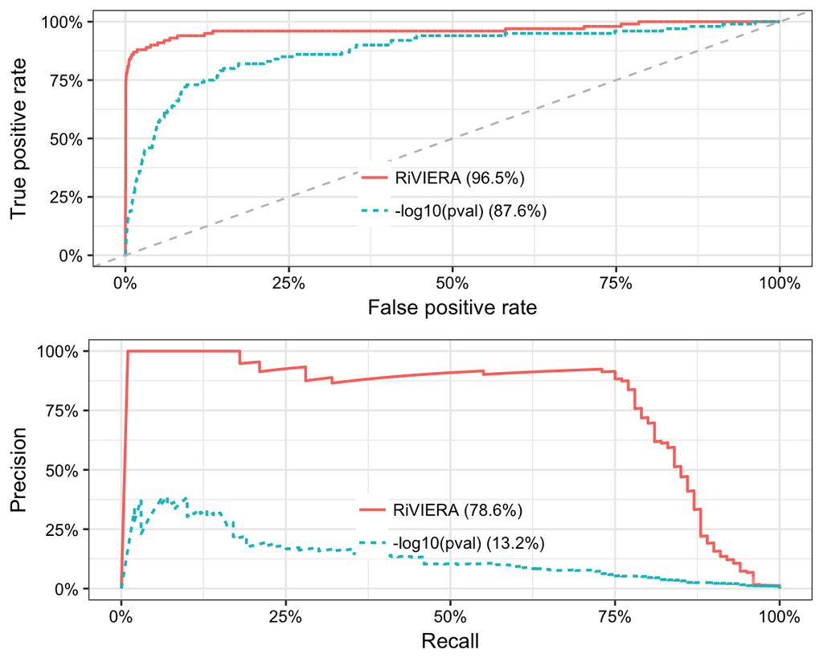

```r
library(gridExtra)

grid.arrange(evalLinePlot(powanal_roc, "ROC"), evalLinePlot(powanal_prc, "PRC"))
```

### Group-guided sparse enrichment learning

The RiVIERA-ridge assumes that the annotations are independent from each other and uses L2-norm (i.e., zeor-mean standard normal prior) to regularize enrichments. However, often the annotations are correlated with each other due to the shared basic regulatory elements. As a result, a naive model will give much interpretable enrichment estimates. Here we address this challenge by harnessing the metadata information about the annotations.

For instance, the group information can be the group of primariy tissue or cell types. Within each tissue type, there are further refinement on the cell-type-specific annotations. For instance, we can have immune as a general cell group, and under “immune” category, we have different immune cell-types such as T cell, B cells, etc. The basic idea is therefore to iteratively infer the enrichment at the cell-group level and then dissect the cell-type-specific enrichment within the group that exhibit high enrichment.

For illustration purpose, we use Multiple Sclerosis GWAS data as an example. For annotatations, we took 52 non-cell-type specific baseline annotations and 220 cell-type-specific annotatoins that are grouped into 10 cell-groups, namely adrenal/pancreas, cardiovascular, central nervous system (CNS), connective/bone, gastrointestinal, immune, kidney, liver, skeletal muscle, and others (Finucane et al., Nature genetics 2015). These annotations were obtained from the LD score regression database (https://data.broadinstitute.org/alkesgroup/LDSCORE/).

We run our model with L2-norm on the baseline annotatoins and group-lasso prior (L1/L2-norm) on the cell-type-specific annotations. The goal is to find out what cell-type-specific annotations are enriched from Multiple Sclerosis genetic signals.

Here we impose a sparsity (groupScoreThres) of 0.9, which at each iteration will focus on learning only the annotatoins within the cell group that has enrichment z-score greater than 90% of the maximum z-scores over all of the 10 cell groups.

```r
gwasData <- system.file("extdata/Multiple_sclerosis.RData", package="RiVIERA")

if(!file.exists(gwasData)) {
  gwasData <- "~/Projects/haploriv/data/sumstats_genomewide_priorityPrunerOutputs_annot/Multiple_sclerosis.RData"
}

load(gwasData)

library(openxlsx)

metadata <- system.file("extdata/Multiple_sclerosis.RData", package="RiVIERA")

if(!file.exists(metadata)) {
  metadata <- "~/Projects/riviera/database/LDSCORE/all/epiref.xlsx"
}

epiref <- read.xlsx(metadata)

cellgroup <- unique(epiref$cellgroup)

pval <- 2*pnorm(-abs(zscore))

groupMat <- matrix(0, length(cellgroup), nrow(epiref))

for(j in 1:length(cellgroup)) {

  groupMat[j,] <- epiref$cellgroup %in% cellgroup[j]
}

groupMat_dummy <- cbind(diag(ncol(ann_bl)+1), matrix(0, ncol(ann_bl)+1, ncol(ann_ct)))

groupMat_ct <- cbind(matrix(0, length(cellgroup), ncol(ann_bl)+1), groupMat)

groupMat <- rbind(groupMat_dummy, groupMat_ct)

annMat <- cbind(1, ann_bl, ann_ct)

# zero-based
targetGroups <- tail(1:nrow(groupMat),length(cellgroup))-1

annGroupNames <- c("dummy", colnames(ann_bl), cellgroup)

targetGroupNames <- annGroupNames[tail(1:nrow(groupMat),length(cellgroup))]

groupScoreThres <- 0.9

res <- riviera_glass(pval=pval,
                     ann=annMat,
                     groupMat=groupMat,
                     targetGroups=targetGroups,
                     targetGroupNames=targetGroupNames,
                     minPval=1e-50,
                     alpha0=0.1,
                     pri0=1e-3,
                     epsilon=0.1,
                     thres=1e-3,
                     max_iter=10,
                     groupScoreThres=groupScoreThres,
                     verbose=1)
```

```
## Estimate parameters by model by EM:
## iter 1: lpr = -3.83483e+06; K = 273; G = 63; alpha = 0.1; pri0 = 0.001; diff = 1
## iter 2: lpr = -3.77167e+06; alpha = 0.110755; pri0 = 0.00101157; diff = 0.0167472
## iter 3: lpr = -3.74239e+06; alpha = 0.1139; pri0 = 0.00102285; diff = 0.00782454
## iter 4: lpr = -3.7229e+06; alpha = 0.115501; pri0 = 0.0010328; diff = 0.00523526
## iter 5: lpr = -3.70772e+06; alpha = 0.116831; pri0 = 0.00104137; diff = 0.00409435
## iter 6: lpr = -3.69495e+06; alpha = 0.118131; pri0 = 0.00104871; diff = 0.00345366
## iter 7: lpr = -3.68386e+06; alpha = 0.119439; pri0 = 0.00105497; diff = 0.00301221
## iter 8: lpr = -3.67401e+06; alpha = 0.120756; pri0 = 0.00106029; diff = 0.00267968
## iter 9: lpr = -3.66514e+06; alpha = 0.122077; pri0 = 0.00106483; diff = 0.0024201
## iter 10: lpr = -3.65705e+06; alpha = 0.123396; pri0 = 0.00106868; diff = 0.00221409
```

```r
K <- ncol(ann_ct)

ann_w <- tail(res$ann_w, K)

rownames(ann_w) <- tail(colnames(annMat), K)

#### significance test ####
scaler <- 1.96 # 95% CI

ann_w_se <- tail(res$ann_w_se[-1],K) # remove intercept

upper <- ann_w + scaler * ann_w_se
lower <- ann_w - scaler * ann_w_se

ann_w_zscore <- tail(res$ann_w_zscore, K)

enrichment <- data.frame(enrichment_zscore=ann_w_zscore,
                         ann_w=ann_w, w_se=ann_w_se,
                         ann_w_pval = 2*pnorm(-abs(ann_w_zscore)),
                         upper=upper, lower=lower)

rownames(enrichment) <- rownames(ann_w)

enrichW <- cbind(epiref[match(rownames(enrichment), epiref$file_number),], enrichment)

enrichW <- enrichW[order(enrichW$enrichment_zscore, decreasing=TRUE),]

print(table(subset(enrichW, ann_w!=0)$cellgroup))
```

```
##
## Immune
##     67
```

```r
print(head(subset(enrichW, ann_w!=0)))
```

```
##     file_number                cell_type    mark cellgroup cellgroup_color
## 194         194                      Th2 H3K27ac    Immune         #4DAF4A
## 193         193                      Th1 H3K27ac    Immune         #4DAF4A
## 191         191 CD25-_IL17-_Th_stim_MACS H3K27ac    Immune         #4DAF4A
## 68           68        CD19_primary_(UW) H3K4me1    Immune         #4DAF4A
## 22           22       CD4_memory_primary H3K4me1    Immune         #4DAF4A
## 54           54             Fetal_thymus H3K4me1    Immune         #4DAF4A
##     mark_color enrichment_zscore     ann_w      w_se ann_w_pval     upper
## 194    #1B9E77          2.223521 0.3336744 0.1500658 0.02618071 0.6278034
## 193    #1B9E77          1.876174 0.2925075 0.1559064 0.06063143 0.5980840
## 191    #1B9E77          1.645306 0.2634399 0.1601160 0.09990663 0.5772672
## 68     #D95F02          1.464116 0.2500348 0.1707752 0.14316219 0.5847543
## 22     #D95F02          1.345166 0.3001163 0.2231073 0.17857169 0.7374065
## 54     #D95F02          1.338820 0.2025833 0.1513149 0.18062943 0.4991604
##           lower
## 194  0.03954545
## 193 -0.01306905
## 191 -0.05038747
## 68  -0.08468467
## 22  -0.13717397
## 54  -0.09399383
```

From the above enrichments, we can see that due to the sparsity we impose over the group the annotatoins in the 67 annotatoins in the immune group that the only ones that have non-zero enrichments for MS. This is consistent with the disease biology. After this step, we can also fit the fine-mapping model using the sparse enrichment weights (ann_w) disregarding the weights that are zeros.

## References

Yue Li, Jose Davilla-Velderrain, Manolis Kellis (2017) A probabilistic framework to dissect functional cell-type-specific regulatory elements and risk loci underlying the genetics of complex traits. bioRxiv